# Figure 3

Damian Wollny

March 09, 2022

```r
# Setup
library(tidyverse)
library(Rmpfr)
library(mgcv)
library(RColorBrewer)
library(seqinr)
library(Biostrings)

theme_set(theme_classic(base_size=22))

# --- colors for this figure

# color: "spectral"
fig3_cols <- brewer.pal(n = 10, name = "Spectral")
fig3_cols[5] <- "#fdcc3f"
fig3_cols[6] <- "#d5ee52"

# function to make colors transparent
makeTransparent = function(..., alpha=0.5) {
  if(alpha<0 | alpha>1) stop("alpha must be between 0 and 1")
  alpha = floor(255*alpha)
  newColor = col2rgb(col=unlist(list(...)), alpha=FALSE)
  .makeTransparent = function(col, alpha) {
    rgb(red=col[1], green=col[2], blue=col[3], alpha=alpha, maxColorValue=255)
  }
  newColor = apply(newColor, 2, .makeTransparent, alpha=alpha)
  return(newColor)
}
```

```r
# Load seq data
master <- readRDS(file = "../_input/coacervate_data.RDS")
```

## Figure 3a

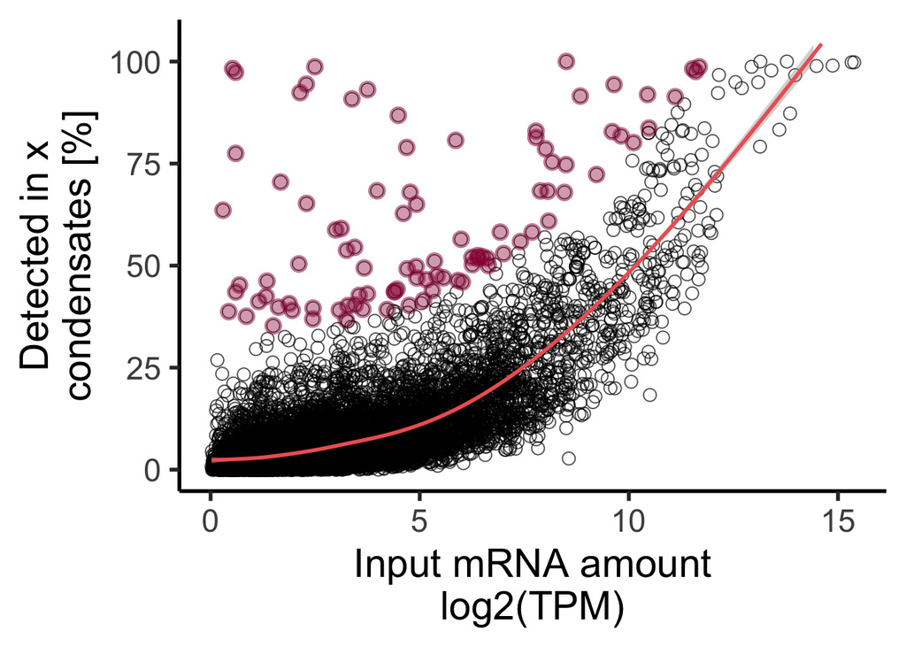

```r
# --- OOL17 replicate ------------------

ool17_input_tpm <- master %>%
  filter(experiment == "ool17_input") %>%
  filter(tpm != 0) %>%
  group_by(target_id) %>%
  summarise(input_tpm = log2_tpm)

ool17_bens_plot <- master %>%
  filter(tpm != 0) %>%
  filter(experiment == "ool17") %>%
  group_by(target_id) %>%
  summarise(count = n()) %>%
  left_join(ool17_input_tpm, ., by="target_id") %>%
  mutate(count = replace(count, which(is.na(count)), 0)) %>% # include all transcripts that are found in 0 coac
  mutate(percent = count*100/max(count))

# --- OOL18 replicate ------------------

ool18_input_tpm <- master %>%
  filter(experiment == "ool18_input") %>%
  filter(tpm != 0) %>%
  group_by(target_id) %>%
  summarise(input_tpm = log2_tpm)

ool18_bens_plot <- master %>%
  filter(tpm != 0) %>%
  filter(experiment == "ool18") %>%
  group_by(target_id) %>%
  summarise(count = n()) %>%
  left_join(ool18_input_tpm, ., by="target_id") %>%
  mutate(count = replace(count, which(is.na(count)), 0)) %>% # include all transcripts that are found in 0 coac
  mutate(percent = count*100/max(count))

# --- Ave ------------------

# Filter all transcripts that are present in both replicate experiments
ave_bens_plot <- inner_join(ool17_bens_plot, ool18_bens_plot, by = "target_id")

# Calc ave(input_tpm) and ave(percent) for each transcript
ave_bens_plot <- ave_bens_plot %>%
  mutate(input_tpm = (input_tpm.x+input_tpm.y)/2) %>%
  mutate(percent = (percent.x+percent.y)/2) %>%
  select(target_id, input_tpm, percent)

# get residuals from model describing data in bens_plot
ave_bens_plot_model <- gam(percent ~ s(input_tpm, bs = "cs"), data = ave_bens_plot)
ave_bens_plot <- ave_bens_plot %>% mutate(residuals = ave_bens_plot_model$residuals)

# plot
fig3a <- ggplot(data = ave_bens_plot, aes(x = input_tpm, y = percent)) +
  geom_point(size = 3, alpha = .7, shape = 21) +
  geom_point(data = ave_bens_plot %>% filter(residuals > 30), color = fig3_cols[1], size = 4, alpha = 0.4) +
  stat_smooth(col = "indianred2") +
  scale_y_continuous(limits = c(0,105)) +
  labs(x = "Input mRNA amount\nlog2(TPM)", y = "Detected in x\ncondensates [%]")
plot(fig3a)
```

## Figure 3b

In order to obtain the input data for this figure, MEME was run as described in the manuscript (see Materials & Methods - Code in ./_meme/ ). The MEME output was then parsed using the custom python script ’./_meme/meme_parser_simple.py’ which can be found in this folder.

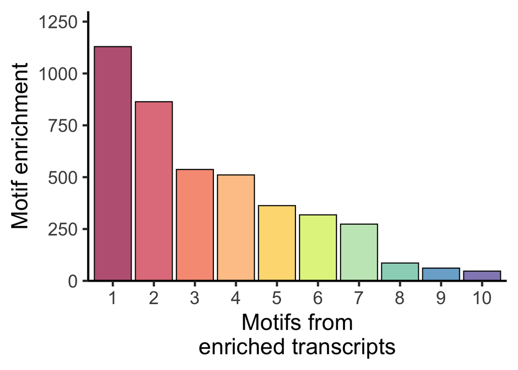

```r
# Several tricks had to be used to work with very small numbers (E-values)
# 1.) colClasses of the e_values had to be converted to a character when reading csv
# 2.) mpfr function from the Rmpfr package needed to be used to read the small numbers. Takes char as input
# 3.) mpfr output was log converted and transformed into numeric

test <- read.csv(file = "./_meme/enr_meme.csv", colClasses = c("e_value" = "character"))
test$e_value <- as.numeric(log(mpfr(test$e_value)))
test$e_value <- test$e_value*-1

# convert 'motif' column to factor and reorder levels according to e_value (for plotting)
test$motif <- factor(test$motif, levels = reorder(test$motif,test$e_value))

# define colors (for plottting)
fig3b1_cols = makeTransparent(fig3_cols, alpha = 0.7)
# plot:

fig3b1 <- ggplot(data = test, aes(x=motif, y=e_value, fill = motif)) +
  geom_bar(stat = "identity", color = "black") +
  scale_y_continuous(expand = c(0,0), limits = c(0,1300)) +
  scale_fill_manual(values=fig3b1_cols) +
  scale_x_discrete(breaks=c(as.character(test$motif)), labels=c(1:10)) +
  theme(legend.position = "none",
        axis.title.x=element_blank(),
        axis.text.x=element_blank(),
        axis.title.y=element_blank(),
        axis.text.y=element_text(angle = 90, hjust = .5, size = 24))

fig3b1_axis <- ggplot(data = test, aes(x=motif, y=e_value, fill = motif)) +
  geom_bar(stat = "identity", color = "black") +
  scale_y_continuous(expand = c(0,0), limits = c(0,1300)) +
  scale_fill_manual(values=fig3b1_cols) +
  scale_x_discrete(breaks=c(as.character(test$motif)), labels=c(1:10)) +
  theme(legend.position = "none") +
  labs(x = "Motifs from\nenriched transcripts", y = "Motif enrichment")
plot(fig3b1_axis)
```

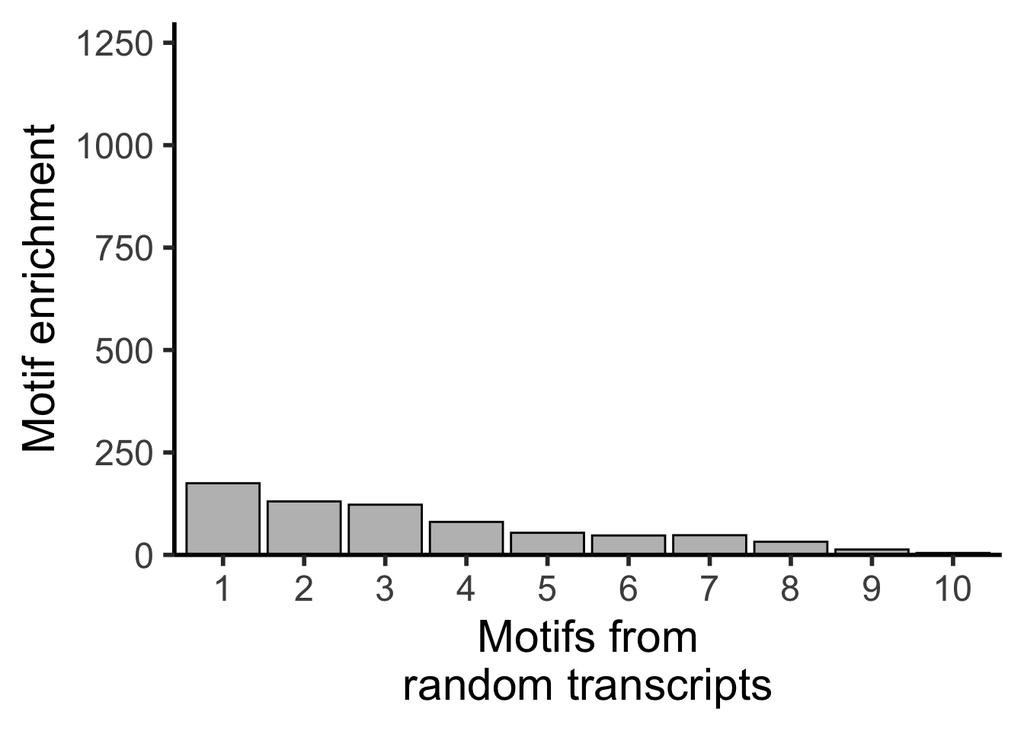

```r
# --- meme output for random transcripts ---------

meme_random <- read.csv(file = "./_meme/rand_meme.csv", colClasses = c("e_value" = "character"))
meme_random$e_value <- as.numeric(log(mpfr(meme_random$e_value)))
meme_random$e_value <- meme_random$e_value*-1

# convert 'motif' column to factor and reorder levels according to e_value (for plotting)
meme_random$motif <- factor(meme_random$motif, levels = reorder(meme_random$motif,meme_random$e_value))

# define colors (for plotting)
fig3b2_cols = rep("grey",10)

# plot:
fig3b2 <- ggplot(data = meme_random, aes(x=motif, y=e_value, fill = motif)) +
  geom_bar(stat = "identity", color = "black") +
  scale_y_continuous(expand = c(0,0), limits = c(0,1300)) +
  scale_fill_manual(values=fig3b2_cols) +
  theme(legend.position = "none",
        axis.title.x=element_blank(),
        axis.text.x=element_blank(),
        axis.title.y=element_blank(),
        axis.text.y=element_text(angle = 90, hjust = .5, size = 24))

fig3b2_axis <- ggplot(data = meme_random, aes(x=motif, y=e_value, fill = motif)) +
  geom_bar(stat = "identity", color = "black") +
  scale_y_continuous(expand = c(0,0), limits = c(0,1300)) +
  scale_fill_manual(values=fig3b2_cols) +
  scale_x_discrete(breaks=c(as.character(meme_random$motif)), labels=c(1:10)) +
  theme(legend.position = "none") +
  labs(x = "Motifs from\nrandom transcripts", y = "Motif enrichment")

plot(fig3b2_axis)
```

## Figure 3c

For this analysis, MAST output was obtained as described in the manuscript (see Materials & Methods - Code in ./_mast/ folder). MAST output was parsed using the ‘mast_parser.py’ script.

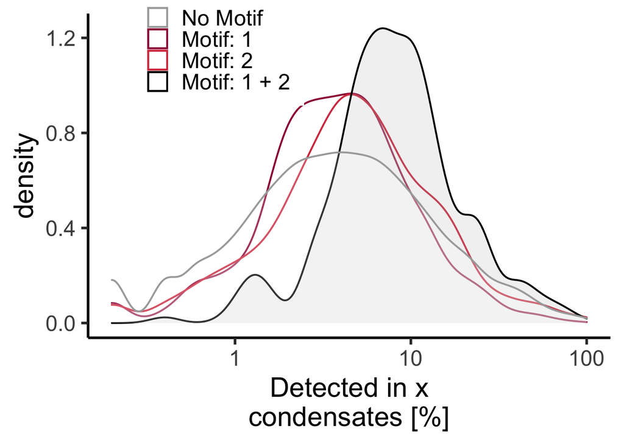

```r
# read mast analysis for ave_pdda_M1 using e_val cutoff 0.05
motif1_test <- readRDS(file = "./_mast/_enr/ave_pdda_m1.RDS")
# read mast analysis for ave_pdda_random using e_val cutoff 0.05
motif1_test.1 <- readRDS(file = "./_mast/_rand/ave_pdda_random.RDS")


fig3c <- ave_bens_plot %>% inner_join(.,motif1_test.1, by = "target_id") %>%
  mutate(index = if_else(count == 2, 3, if_else(strand == "+", 1, 2))) %>%
  ggplot(aes(x = percent, color = as.factor(index))) +
  geom_density(aes(fill = as.factor(index)), alpha = 0.2, size = .7) +
  geom_density(data = ave_bens_plot %>% anti_join(.,motif1_test.1, by = "target_id") %>% mutate(index = 0), aes(fill = as.factor(index)), alpha = 0.2, size = .7) +
  scale_color_manual(values=c( "darkgrey", fig3_cols[1], fig3_cols[2], "black"),
                     breaks=c("0","1", "2", "3"),
                     labels=c("No Motif", "Motif: 1", "Motif: 2", "Motif: 1 + 2")) +
  scale_fill_manual(values = c("white", "white", "white", "grey")) +
  scale_x_continuous(trans = "log10") +
  labs(x = "Detected in x\ncondensates [%]") +
  theme(legend.title = element_blank(), legend.position = c(0.25,0.91)) +
  guides(fill=FALSE)

plot(fig3c)
```

## Figure 3d

For the pairwise alignment analysis of each transcrip with it’s reverse complement, we used the sequences for all transcripts (e.g. ./_sw_analysis/pdda_input_rand_seqs.txt) and ran a script to get local pairwise alignment (e.g. ./_sw_analysis/pdda_pairwise_alignment_cluster_both.R) on a cluster. The output was then combined in a .RDS file which was the input for this figure.

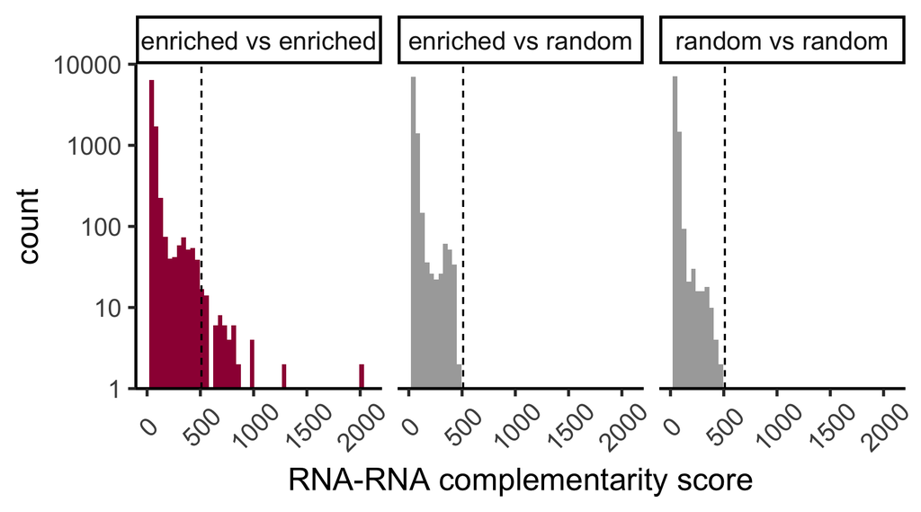

```r
comb <- readRDS(file = "./_sw_analysis/comb_data.RDS")

# convert 'transcripts' col to factor and change level for facet labels
comb$transcripts <- as.factor(comb$transcripts)
levels(comb$transcripts) <- c("enriched vs enriched", "enriched vs random", "random vs random")

# histogram: distribution of SW-scores
fig3d <- ggplot(data = comb, aes(value)) +
  geom_histogram(aes(fill = transcripts), bins = 50) +
  facet_grid(. ~ transcripts) +
  scale_fill_manual(values = c(fig3_cols[1], "darkgrey", "darkgrey")) +
  scale_y_continuous(trans = "log10", expand = c(0,0)) +
  xlim(c(0,2100)) +
  geom_segment(aes(x = 510, y = 1, xend = 510, yend = 1e4), linetype = 2, color = "black") +
  labs(x = "RNA-RNA complementarity score") +
  theme(legend.position = "none", strip.text.x = element_text(size = 18),
        axis.text.x = element_text(size = 18, angle = 45, vjust = .6))

plot(fig3d)
```

## Figure 3e

SINE/ALU sequences were obtained from Repbase: https://www.girinst.org/server/RepBase/index.php

Among the files the humsub.ref was used to get the SINE sequences (can be found in ./sines). Sequences of individual motifs discovered by MEME were parsed using the script “./sines/meme_parser_get_ind_motifs.py”

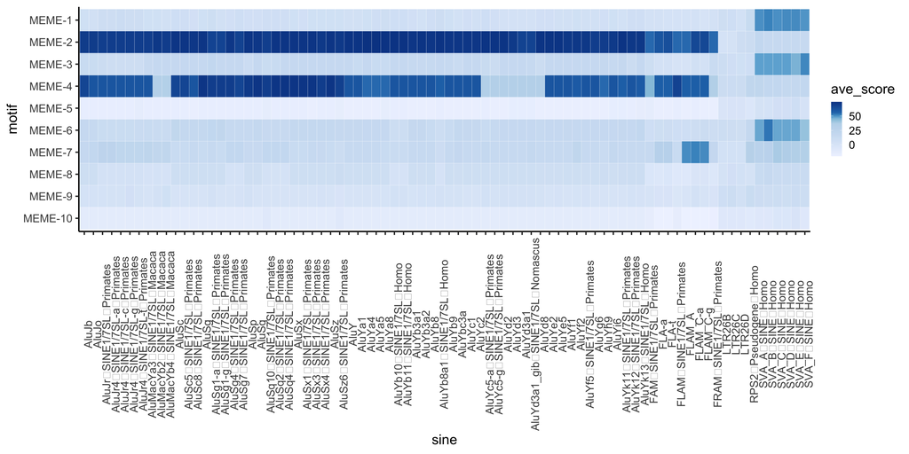

```r
# function to get the reverse complement of given seq
get_reverse_compl <- function(seq){
  reverse(chartr("ATGC","TACG",seq))
}

# Read Sine sequences obtained from RepBase
sines <- read.fasta("./_sines/humsub_gatc.fa")

# Parse fasta into df
sine_df <- data.frame(sine = character(),
                      sine_seq = character(),
                      stringsAsFactors=FALSE)

for (i in 1:length(sines)){
  sine_df[i,1] <- names(sines[i])
  sine_df[i,2] <- toupper(c2s(sines[[i]]))
}

# Read individual motifs from meme analysis - ENRICHED
ind_motifs_enr <- read.csv(file = "./_sines/meme_ind_motifs.csv")
ind_motifs_enr_top <- ind_motifs_enr %>%
  group_by(motif_number) %>%
  filter(row_number() <= 5) %>%
  modify_if(is.factor, as.character) %>%
  as.data.frame() %>%
  mutate(rc_motif_seqs = get_reverse_compl(motif_seqs))

# Define output df
output_df <- data.frame(sine = character(),
                        motif = character(),
                        align_score = numeric(),
                        motif_source = character(),
                        stringsAsFactors = FALSE)

# Setup Substitution matrix for alignment
sigma <- nucleotideSubstitutionMatrix(match = 2, mismatch = -1, baseOnly = TRUE)

x = 0
for (j in 1:nrow(sine_df)){
  for (n in 1:nrow(ind_motifs_enr_top)) {
    x = x + 1
    output_df[x,1] <- sine_df$sine[j]
    output_df[x,2] <- ind_motifs_enr_top[n,1]
    output_df[x,3] <- pairwiseAlignment(sine_df[j,2], as.character(ind_motifs_enr_top[n,2]), substitutionMatrix = sigma, gapOpening = -10,
                      gapExtension = 0, scoreOnly = TRUE)
    output_df[x,4] <- "enriched"
  }
}

# plot
output_df %>%
  filter(motif_source == "enriched") %>%
  mutate(motif = factor(motif, levels = rev(c("MEME-1", "MEME-2", "MEME-3", "MEME-4", "MEME-5",
                                          "MEME-6", "MEME-7", "MEME-8", "MEME-9", "MEME-10")))) %>%
  group_by(sine,motif) %>%
  summarise(ave_score = mean(align_score)) %>%
  ggplot(aes(x = sine, y = motif, fill = ave_score)) +
  geom_tile(color = "white") +
  scale_fill_distiller(palette="Blues", direction=1, values = rev(c(1.0,0.8,0.75,0.7,0.6,0))) +
  theme(axis.text.x = element_text(angle = 90))
```